# Breast Cancer Survival Analysis

Modified

October 3, 2025

## Data Cleaning

Load packages:

```r
library(tidyverse)
```

Load data. We select only the first 31 rows of the data as the rest are RNA profiles:

```r
data <- read.csv("../data/METABRIC_RNA_Mutation.csv")

# first 31 rows are clinical attributes; rest is RNA expression data
data_selected <- data |> select(1:31)
```

Checking for duplicates:

```r
any(duplicated(data_selected))
```

```
[1] FALSE
```

There are no duplicates in the data. Now we look for variables with missing values:

```r
# check variables with missing values
colSums(is.na(data_selected))
```

```
                    patient_id               age_at_diagnosis
                             0                              0
        type_of_breast_surgery                    cancer_type
                             0                              0
          cancer_type_detailed                    cellularity
                             0                              0
                  chemotherapy    pam50_._claudin.low_subtype
                             0                              0
                        cohort      er_status_measured_by_ihc
                             0                              0
                     er_status      neoplasm_histologic_grade
                             0                             72
  her2_status_measured_by_snp6                    her2_status
                             0                              0
tumor_other_histologic_subtype                hormone_therapy
                             0                              0
     inferred_menopausal_state            integrative_cluster
                             0                              0
      primary_tumor_laterality  lymph_nodes_examined_positive
                             0                              0
                mutation_count    nottingham_prognostic_index
                            45                              0
                 oncotree_code        overall_survival_months
                             0                              0
              overall_survival                      pr_status
                             0                              0
                 radio_therapy     X3.gene_classifier_subtype
                             0                              0
                    tumor_size                    tumor_stage
                            20                            501
             death_from_cancer
                             0
```

From the above output: * mutation_count, neoplasm_histologic_grade, tumor_size and tumor_stage have missing values.

- tumor_size (missing 20) and tumor_stage (missing 501) are variables important to the research question, so for those we found exactly what proportion were missing:

```r
# how many patients with missing tumor size-- proportion of total patients
mean(is.na(data_selected$tumor_size))
```

```
[1] 0.0105042
```

Since there are 20 patients with missing tumour sizes, which is only ~1% of the number of patients in the dataset, these rows were dropped.

Now investigate missing tumor stage values:

```r
# how many patients with missing tumor stage-- proportion of total patients
mean(is.na(data_selected$tumor_stage))
```

```
[1] 0.2631303
```

```r
tapply(data$overall_survival, is.na(data_selected$tumor_stage), summary)
```

```
$`FALSE`
   Min. 1st Qu.  Median    Mean 3rd Qu.    Max.
 0.0000  0.0000  0.0000  0.4355  1.0000  1.0000

$`TRUE`
   Min. 1st Qu.  Median    Mean 3rd Qu.    Max.
 0.0000  0.0000  0.0000  0.3792  1.0000  1.0000
```

Patients with missing tumor stage had a lower mean overall survival rate (37.9%) compared to those with recorded tumor stage (43.6%), suggesting missingness may not be completely random. This should be considered when interpreting results.

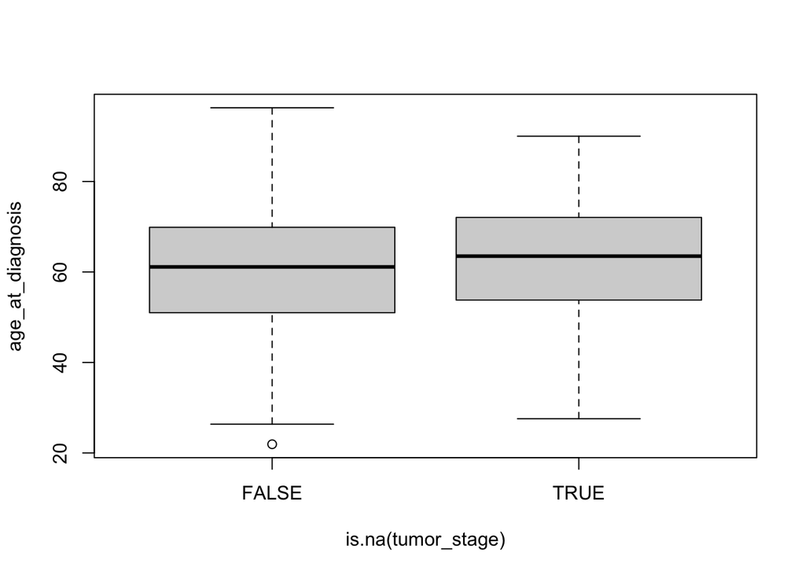

```r
# check if patients with missing have different ages

boxplot(age_at_diagnosis ~ is.na(tumor_stage), data = data_selected)
```

From the comparative boxplot, those with missing tumor stage values seem to be older on average. To confirm this, we run a Welch Two Sample t-test:

```r
t.test(age_at_diagnosis ~ is.na(tumor_stage), data = data_selected)
```

```
    Welch Two Sample t-test

data:  age_at_diagnosis by is.na(tumor_stage)
t = -2.8269, df = 887.82, p-value = 0.004806
alternative hypothesis: true difference in means between group FALSE and group TRUE is not equal to 0
95 percent confidence interval:
 -3.2156707 -0.5802653
sample estimates:
mean in group FALSE  mean in group TRUE
           60.58764            62.48561
```

p = 0.004806 (p < 0.05) so the differences in ages are significant.

```r
# Create group subsets
group_false <- data$age_at_diagnosis[!is.na(data_selected$tumor_stage)]
group_true  <- data$age_at_diagnosis[is.na(data_selected$tumor_stage)]

# code for qqplots

# qqnorm(group_false, main = "Q-Q Plot: Group FALSE")
# qqline(group_false, col = "red")
# qqnorm(group_true, main = "Q-Q Plot: Group TRUE")
# qqline(group_true, col = "blue")
```

```r
mean1 <- mean(group_false)
mean2 <- mean(group_true)

sd1 <- sd(group_false)
sd2 <- sd(group_true)

cohens_d <- (mean1 - mean2) / sqrt((sd1^2 + sd2^2) / 2)
cohens_d
```

```
[1] -0.146815
```

There is a statistically significant difference in age between patients with missing and non-missing tumor_stage (p = 0.0048), although the effect size is small (Cohen’s d = −0.15). Because age is a predictor in the study, this suggests missingness in tumor_stage may not be completely random.

Due to the scope of this project, we will drop these cases but note this as a potential source of bias in downstream analysis.

```r
n_before <- nrow(data_selected)
data_clean <- data_selected |>
  filter(!is.na(tumor_stage), !is.na(tumor_size)) |>
  select(
    age_at_diagnosis,                       # predictor
    tumor_stage,                            # predictor
    tumor_size,                             # predictor
    her2_status,                            # predictor
    lymph_nodes_examined_positive,         # predictor
    neoplasm_histologic_grade,              # possible confounder/prognostic factor
    nottingham_prognostic_index,            # possible confounder/prognostic factor
    er_status,                              # possible confounder
    pr_status,                              # possible confounder
    her2_status_measured_by_snp6,          # measurement method detail
    overall_survival_months,               # outcome
    overall_survival,                      # outcome indicator
    death_from_cancer                      # outcome indicator
  )

n_after <- nrow(data_clean)

cat("Dropped", n_before - n_after, "rows (", round((n_before - n_after) / n_before * 100, 1), "% of dataset )\n")
```

```
Dropped 504 rows ( 26.5 % of dataset )
```

Lastly, change data types to correct format:

```r
data_clean <- data_clean |>
  mutate(
    tumor_stage = as.factor(tumor_stage),
    her2_status = as.factor(her2_status),
    er_status = as.factor(er_status),
    pr_status = as.factor(pr_status),
    her2_status_measured_by_snp6 = as.factor(her2_status_measured_by_snp6),
    death_from_cancer = as.factor(death_from_cancer),
    neoplasm_histologic_grade = as.factor(neoplasm_histologic_grade)
  )
```

```r
nrow(data_clean)
```

```
[1] 1400
```

```r
write.csv(data_clean, "../data/data_clean.csv", row.names = FALSE)
glimpse(data_clean)
```

```
Rows: 1,400
Columns: 13
$ age_at_diagnosis              <dbl> 75.65, 43.19, 48.87, 47.68, 76.97, 78.77…
$ tumor_stage                   <fct> 2, 1, 2, 2, 2, 4, 2, 2, 2, 2, 4, 1, 2, 2…
$ tumor_size                    <dbl> 22, 10, 15, 25, 40, 31, 10, 29, 16, 28, …
$ her2_status                   <fct> Negative, Negative, Negative, Negative, …
$ lymph_nodes_examined_positive <dbl> 10, 0, 1, 3, 8, 0, 1, 1, 1, 0, 0, 0, 3, …
$ neoplasm_histologic_grade     <fct> 3, 3, 2, 2, 3, 3, 2, 2, 3, 2, 2, 1, 3, 3…
$ nottingham_prognostic_index   <dbl> 6.044, 4.020, 4.030, 4.050, 6.080, 4.062…
$ er_status                     <fct> Positive, Positive, Positive, Positive, …
$ pr_status                     <fct> Negative, Positive, Positive, Positive, …
$ her2_status_measured_by_snp6  <fct> NEUTRAL, NEUTRAL, NEUTRAL, NEUTRAL, NEUT…
$ overall_survival_months       <dbl> 140.50000, 84.63333, 163.70000, 164.9333…
$ overall_survival              <int> 1, 1, 0, 1, 0, 0, 1, 0, 0, 0, 0, 1, 1, 0…
$ death_from_cancer             <fct> Living, Living, Died of Disease, Living,…
```